# PD nr 4

Jakub Szypuła

14/11/2019

## Oryginalny wykres

Tutaj znajduje się oryginalny wykres, który poprawiam:

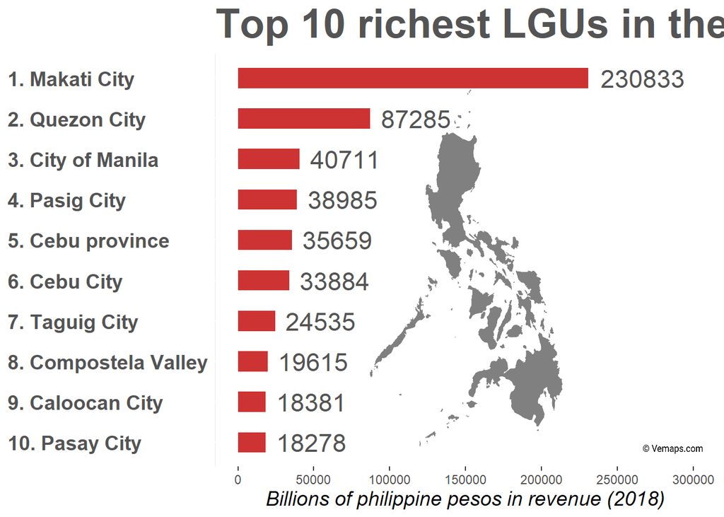

## Nowy wykres

Tutaj zaś znajduje się moja poprawiona wersja:

[figure not shown]

## Uzasadnienie

Uważam, że następujące zmiany, które wprowadziłem były pomocne, byłoby też je trudniej wprowadzić kodem R-owym, niż programem inkscape:

- dodanie gradientów do kolumn, wybranie kolorów w tym programie graficznym i uzupełnianie tego na żywo pozwala na znacznie łatwiejszy dobór odpowiednich kolorów (ewentualnie jak w moim przypadku wybranie dokładnie takich kolorów jak w wykresie, na podstawie którego został zrobiony pierwszy wykres w tym dokumencie)
- dodanie czerwonej kreski na poziomie 0, żeby “zaczepić” słupki
- dodanie symbolu peso filipińskiego do pól z walutą, co w oryginale wymagałoby podpisania kolumn ręcznie
- dodanie półprzeźroczystych linii pomocniczych, które pozwalają lepiej określić wysokość (a raczej długość) słupków
- osiągnięcie kompromisu między oryginalnym-oryginalnym wykresem (mapa Filipin w tle, nachodząca na słupki i napisy), a tym poprawianym przeze mnie (mapa Filipin obok, nieprzezroczysta, która nie nachodzi), czyli ustalenie odpowiedniego alpha na obrazku w tle, zmiana go na wektorowy (dzięki czemu nie będzie problemu przy powiększaniu go i luźnych pikseli) oraz przesunięcie go w taki sposób, żeby nie nachodził na tekst, a górny słupek nie kończył się na nim